# Homework 2 - Euroleague

Alper Kocabiyik

25 May 2018

```r
library(rtweet)
```

```r
library(igraph)
library(dplyr)
library(knitr)
library(wordcloud)
library(tm)
require(rtweet)
require("devtools")
# install_url("http://cran.r-project.org/src/contrib/Archive/Rstem/Rstem_0.4-1.tar.gz")
# install_url("http://cran.r-project.org/src/contrib/Archive/sentiment/sentiment_0.2.tar.gz")
require(syuzhet)
tweets <- search_tweets("euroleague",n=5000,lang="en") # 25-05-2018
```

```
## Searching for tweets...
```

```
## Finished collecting tweets!
```

```r
save(tweets,file="C:/Users/alper/Desktop/data vis 3/twitter_AlperKocabiyik.Rmd")
```

Cleaning the unnecessary characters

```r
texts <- tweets$text
texts <- iconv(texts,"UTF-8","latin1",sub="") #get rid of emojis, end-of-line characters
texts <- gsub("(RT|via)((?:\\b\\W*@\\w+)+)", "", texts) #get rid of retweets
texts = gsub("@\\w+", "", texts) #get rid of mentions
texts = gsub("[[:punct:]]", "", texts) #get rid of punctuation
texts = gsub("[[:digit:]]", "", texts) #get rid of numbers
texts = gsub("http\\w+", "", texts) #get rid of html links
texts = gsub("[ \t]{2,}", "", texts) #get rid of unnecessary spaces
texts = gsub("^\\s+|\\s+$", "", texts)
```

get_sentiment function to find positive or negative tweets.

```r
# to obtain the polarity of the tweets
polarity <- get_sentiment(texts,method="bing")

# define a dataframe with the number of the twwet
polarity.df <- data.frame(n_tweet = c(1:nrow(tweets)), polarity = polarity)
```

```r
# top 10 positive
top.10.positive <- as.vector(polarity.df[1:10,1])
texts[top.10.positive]
```

```
##  [1] "EuroLeague The TopAmerican players of the season \n\nCorry Higgins"
##  [2] "Luka Doncics awards this season\n\nEuroLeague Regular Season MVP\n\nAllEuroLeague st team\n\nEuroLeague Rising Star Trophy"
##  [3] "OneTeam once again put atrisk groups in need of community integration under the spotlight with a series of successful a"
##  [4] "OneTeam once again put atrisk groups in need of community integration under the spotlight with a series of successful a"
##  [5] "lifted theand now you can own one of hisjerseys from theseason with al"
##  [6] "Luka Doncics awards this season\n\nEuroLeague Regular Season MVP\n\nAllEuroLeague st team\n\nEuroLeague Rising Star Trophy"
##  [7] "Lithuanian girllietuva Lithuania zalgiris EuroLeague"
##  [8] "OneTeam once again put atrisk groups in need of community integration under the spotlight with a series of successful activities at theFinal Four in Belgrade"
##  [9] "Luka Doncics awards this season\n\nEuroLeague Regular Season MVP\n\nAllEuroLeague st team\n\nEuroLeague Rising Star Trophy"
## [10] "Luka Doncics awards this season\n\nEuroLeague Regular Season MVP\n\nAllEuroLeague st team\n\nEuroLeague Rising Star Trophy"
```

```r
# top 10 negative
top.10.negative <- as.vector(polarity.df[nrow(polarity.df):(nrow(polarity.df)-9),1])
texts[top.10.negative]
```

```
##  [1] "CHAMPNS\n EUROLEAGUE \nHalaMadridFGlory"
##  [2] "FIBA isnt as organized as FIFAThats why theres no FIBA Club World Championship Basketball in Europe has their own Champions League competitionReal Madrid Baloncesto won last night as EuroLeague Champions"
##  [3] "Why do people in states still thinkis soft I dont think any of the college players would be capable of what"
##  [4] "Two more great additions Olympiacos amp Euroleague top CPF Jamel McLean is joining Octagon Europe along with agent Da"
##  [5] "This EuroLeague Final game is crazy One of the craziest atmospheres Ive ever seen"
##  [6] "Ahmet Duverioglu rattles the rim\n\nThe big man starting strong \n\nDAYSMagicMoment FGLORY"
##  [7] "of the NCAA Tournament would be lucky to sign with a Euroleague club yet alone win every major award and win the damn"
##  [8] "Why do people in states still thinkis soft I dont think any of the college players would be capable of what"
##  [9] "AtLeBron average game in the NBA but Luka Doncic winning EuroLeague MVP at the same age is crazy considering the talent amongst those teams"
## [10] "MVPFinal \n MVP\n Rising Star\n Team of the Year \nCHAMPNS"
```

### a.2) Visualize the Word clouds of the corpus of positive and negative tweets

[figure not shown]

```r
# let create two corpus, one for the positive and one for the negative
# To use it we have to convert our texts (tweets) to a frequency table of the different words use.

texts <- removeWords(texts, stopwords("english")) #get rid of stopwords in english
texts <- removeWords(texts, c("euroleague", 'final'))
#corpus with the tweets (total, negative and positive)
corpus.texts.pos <- Corpus(VectorSource(texts[polarity>0]))
corpus.texts.neg <- Corpus(VectorSource(texts[polarity<0]))

par(mfrow=c(1,2))
wordcloud(corpus.texts.pos, max.words=100, random.order= FALSE, colors=brewer.pal(6,"Dark2"),scale = c(3,.5))
wordcloud(corpus.texts.neg, max.words=100, random.order= FALSE, colors=brewer.pal(6,"Dark2"),scale = c(3,.5))
```

### b) Build the graph of interactions between users using RTs.

```r
activity <- data.frame(table(tolower(tweets$screen_name)))
colnames(activity) <- c("user","ntweets")
tweets$text <- iconv(tweets$text,"UTF-8","ASCII",sub="") #remove characters
tweets$text <- gsub("\n","",tweets$text) #remove end-of-line
rts <- grep("^rt @[a-z0-9_]{1,15}", tolower(tweets$text), perl=T)
head(tweets$text[rts])
```

```
## [1] "RT @Eurohoopsnet: #EuroLeague: The Top 10 American players of the season 1.  Corry Higgins2. @phillybul_22 3. @TheNatural_05 4. @Da_Th"
## [2] "RT @Sportando: Luka Doncics awards this season:EuroLeague Regular Season MVPAll-EuroLeague 1st teamEuroLeague Rising Star Trophy"
## [3] "RT @OTEuroleague: #OneTeam once again put at-risk groups in need of community integration under the spotlight with a series of successful a"
## [4] "RT @OTEuroleague: #OneTeam once again put at-risk groups in need of community integration under the spotlight with a series of successful a"
## [5] "RT @OTEuroleague: .@23Llull lifted the  and now you can own one of his @RMBaloncesto jerseys from the 2017/2018 @EuroLeague season with al"
## [6] "RT @Sportando: Luka Doncics awards this season:EuroLeague Regular Season MVPAll-EuroLeague 1st teamEuroLeague Rising Star Trophy"
```

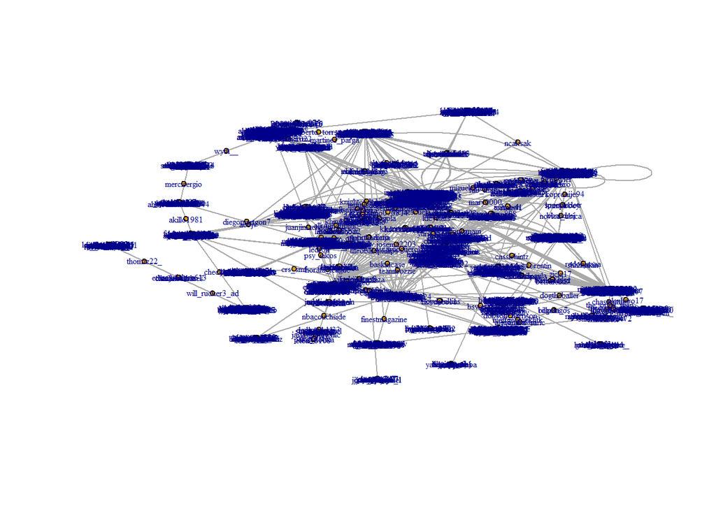

```r
rt.sender <- gsub("^.*@([a-z0-9_]{1,15})+.*$", "\\1",tolower(tweets$screen_name[rts]), perl=T)
rt.receiver <- gsub("^rt @([a-z0-9_]{1,15}):+.*$", "\\1", tolower(tweets$text[rts]), perl=T)
edgelist <- data.frame(rt.sender,rt.receiver,stringsAsFactors=F)
g <- graph.data.frame(edgelist)
cc <- clusters(g)
g0 <- delete.vertices(g,which(cc$membership!=which.max(cc$csize)))
plot(g0,vertex.size=2,edge.arrow.size=.01,asp=5/10,vertex.label.cex=0.5)
```

### c) Calculate the influence of the users in the graph using their Activity, Number of RTs received and Centrality. Report the top 10 most influencing users according to those metrics

```r
degRT <- degree(g0,mode="in") # only incoming RTs
cenRT <- page_rank(g0)$vector

influenceRT <- data.frame(user=V(g0)$name,degRT,cenRT)
influence <- merge(activity,influenceRT)
```

Centrality

```r
head(arrange(influence,desc(cenRT)), 10)
```

```
##               user ntweets degRT      cenRT
## 1       euroleague      52  1296 0.13890298
## 2     oteuroleague       5    20 0.05706173
## 3        sportando      13   229 0.03997553
## 4       bczalgiris       1   208 0.03657320
## 5  sacramentokings       1   155 0.01781692
## 6         hugoboss       1    50 0.01698229
## 7     rmbaloncesto       1   121 0.01403279
## 8  sergiorodriguez       1    33 0.01366344
## 9       cskabasket       5    13 0.01159086
## 10      ballislife       1    89 0.01108641
```

Number of tweets

```r
head(arrange(influence,desc(ntweets)), 10)
```

```
##               user ntweets degRT        cenRT
## 1       michimonti      73     0 0.0001462587
## 2       euroleague      52  1296 0.1389029815
## 3  nolookpassstyle      33     0 0.0001462587
## 4        nottocini      32     0 0.0001462587
## 5      balleragent      30     0 0.0001462587
## 6         arbarkas      25     0 0.0001462587
## 7     eurohoopsnet      25   140 0.0093294466
## 8    kufurbazpablo      18     0 0.0001462587
## 9    rebel_crimson      16     0 0.0001462587
## 10           acbjv      15     0 0.0001462587
```

Degree

```r
head(arrange(influence,desc(degRT)), 10)
```

```
##               user ntweets degRT       cenRT
## 1       euroleague      52  1296 0.138902981
## 2        sportando      13   229 0.039975532
## 3       bczalgiris       1   208 0.036573198
## 4  sacramentokings       1   155 0.017816922
## 5     eurohoopsnet      25   140 0.009329447
## 6     rmbaloncesto       1   121 0.014032787
## 7       ballislife       1    89 0.011086407
## 8        hoopshype       2    54 0.006116720
## 9         hugoboss       1    50 0.016982290
## 10  illegalscreens       3    41 0.006675577
```

### d) Calculate the average polarity of the tweets of the users in the graph and study the correlation between that average and their influence

```r
#Calculating average polarity for each user

user_avg_polarity <- function(users)
{
  polarity.avg <- vector()
  for (user in users){
    text <- tweets$text[tolower(tweets$screen_name) == user]

    text <- iconv(text,"UTF-8","latin1",sub="") #get rid of emojis, end-of-line characters
    text <- gsub("(RT|via)((?:\\b\\W*@\\w+)+)", "", text) #get rid of retweets
    text = gsub("@\\w+", "", text) #get rid of mentions
    text = gsub("[[:punct:]]", "", text) #get rid of punctuation
    text = gsub("[[:digit:]]", "", text) #get rid of numbers
    text = gsub("http\\w+", "", text) #get rid of html links
    text = gsub("[ \t]{2,}", "", text) #get rid of unnecessary spaces
    text = gsub("^\\s+|\\s+$", "", text)

    polarity.all <- get_sentiment(text, method="bing")
    polarity.avg <- c(polarity.avg, sum(polarity.all)/length(text))
  }
  df <- data.frame(user=users, polarity.avg)
  return(df)
}
```

Influence and polarity

```r
user <- V(g0)$name
df <- user_avg_polarity(user)
influence.polarity <- merge(influence,df)
head(arrange(influence.polarity, desc(cenRT)) ,10)
```

```
##               user ntweets degRT      cenRT polarity.avg
## 1       euroleague      52  1296 0.13890298    0.4038462
## 2     oteuroleague       5    20 0.05706173    1.0000000
## 3        sportando      13   229 0.03997553    0.7692308
## 4       bczalgiris       1   208 0.03657320    5.0000000
## 5  sacramentokings       1   155 0.01781692    1.0000000
## 6         hugoboss       1    50 0.01698229    2.0000000
## 7     rmbaloncesto       1   121 0.01403279    2.0000000
## 8  sergiorodriguez       1    33 0.01366344    3.0000000
## 9       cskabasket       5    13 0.01159086    0.6000000
## 10      ballislife       1    89 0.01108641    4.0000000
```

eurolegue official account is the greatest influencer and has a positive polarity as its expected. All other accounts with great influence have positive average polarity too.

According to the average polarity

```r
head(arrange(influence.polarity, desc(polarity.avg)) ,10)
```

```
##               user ntweets degRT        cenRT polarity.avg
## 1      crispiplaya       1     1 0.0001500259            6
## 2       bczalgiris       1   208 0.0365731978            5
## 3         tomcrean       1    17 0.0017693235            5
## 4  viktorijakamaza       1     5 0.0005845288            5
## 5    _fb_ugurerdem       1     0 0.0001462587            4
## 6        _kubi1907       1     0 0.0001462587            4
## 7      _kwilliams3       1     7 0.0008938809            4
## 8         alex10on       1     0 0.0001462587            4
## 9       alifb19007       1     0 0.0001462587            4
## 10     balikcikusu       1     0 0.0001462587            4
```

The one with biggest average polarities dont have a lot influence except ‘bczalgiris’ if we generalize top 10.